# Essential commands (ds4psy)

# Visualizing data

In the following, we introduce some essential commands of `ggplot2` in the context of examples. However, the `ggplot2` package extends far beyond this modest introduction – it is an important pillar (and predecessor) of the `tidyverse` and implements a language for and philosophy of data visualisation.

See [Chapter 3: Data visualization](http://r4ds.had.co.nz/data-visualisation.html)) and [Chapter 7: Exploratory data analysis (EDA)](http://r4ds.had.co.nz/exploratory-data-analysis.html) and the links provided below for more detailed information.

## Commands and examples

### General structure of `ggplot` calls

A generic template for creating a graph with `ggplot` is:

```r
# Generic ggplot template:
ggplot(data = <DATA>) +
  <GEOM_fun>(mapping = aes(<MAPPING>), <arg_1 = val_1, ..., arg_n = val_n>) +
  <FACET_fun> +    # optional
  <LOOK_GOOD_fun>  # optional

# Minimal ggplot template:
ggplot(<DATA>) +
  <GEOM_fun>(aes(<MAPPING>)
```

The generic template includes the following parts:

- `<DATA>` is a data frame or tibble that contains the data that is to be plotted.
- `<GEOM_fun>` is a function that maps data to a *geometric object* (“geom”) according to an aesthetic mapping that are specified in `aes(<MAPPING>)`. (A “mapping” specifies what goes where.)
- A geom’s visual appearance (e.g., colors, shapes, sizes, …) can be customized
  1. in the aesthetic mapping (when varying visual features according to data properties), or
  2. by setting its arguments to specific values in `<arg_1 = val_1, ..., arg_n = val_n>` (when remaining constant).
- An optional `<FACET_fun>` splits a complex plot into multiple subplots.
- A sequence of optional `<LOOK_GOOD_fun>` adjusts the visual features of plots (e.g., by adding themes, plot titles and labels, color scales, and coordinate systems).

Some examples that illustrate the use of these components are:

### A histogram

A *histogram* counts how often specific values of one (typically continuous) variable occur in the data. This allows viewing the distribution of values for this variable:

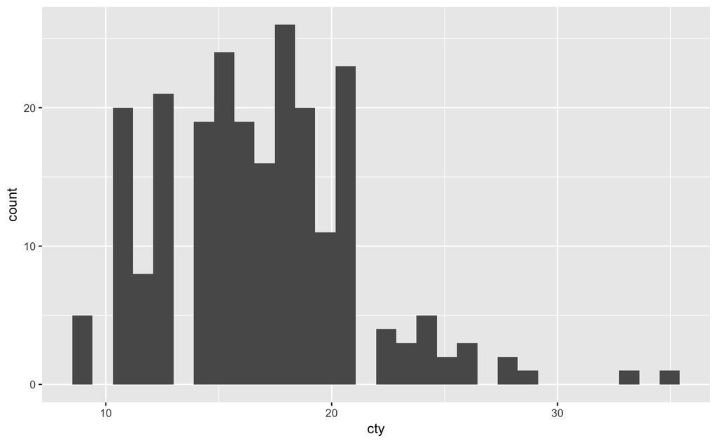

```r
library(ggplot2)

# Data: ------
# Using mpg data:
# ?ggplot2::mpg

# (A) Histogram: ------

# A minimal histogram:
hi1 <- ggplot(mpg, aes(x = cty)) +  # set mappings for ALL geoms
  geom_histogram()
hi1
```

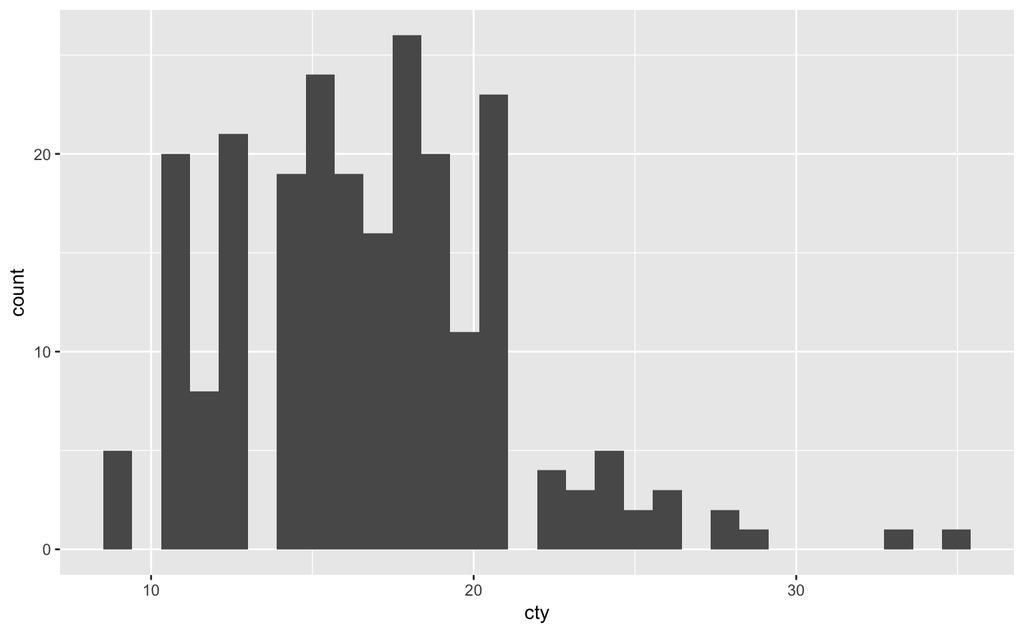

```r
# The same histogram:
hi1b <- ggplot(mpg) +
  geom_histogram(aes(x = cty))      # set mappings for THIS geoms
hi1b
```

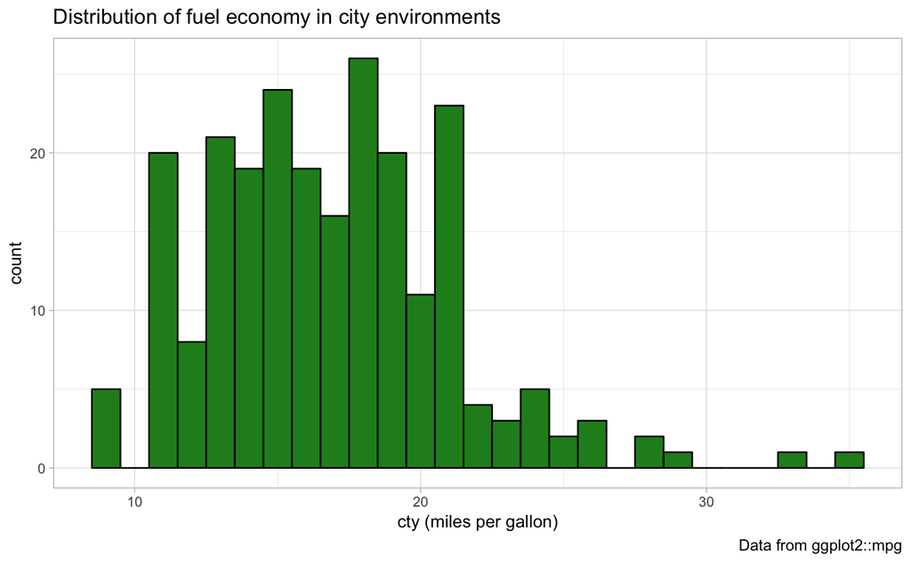

```r
# (B) Adding aesthetics, labels and themes: ------

# Enhanced version of the same plot:
hi2 <- ggplot(mpg) +
  geom_histogram(aes(x = cty), binwidth = 1, fill = "forestgreen", color = "black") +
  labs(title = "Distribution of fuel economy in city environments",
       x = "cty (miles per gallon)",
       caption = "Data from ggplot2::mpg") +
  theme_light()
hi2
```

### A scatterplot

A *scatterplot* shows a data point (observation) as a function of 2 (typically continuous) variables `x` and `y`. This allows judging the relationship between `x` and `y` in the data:

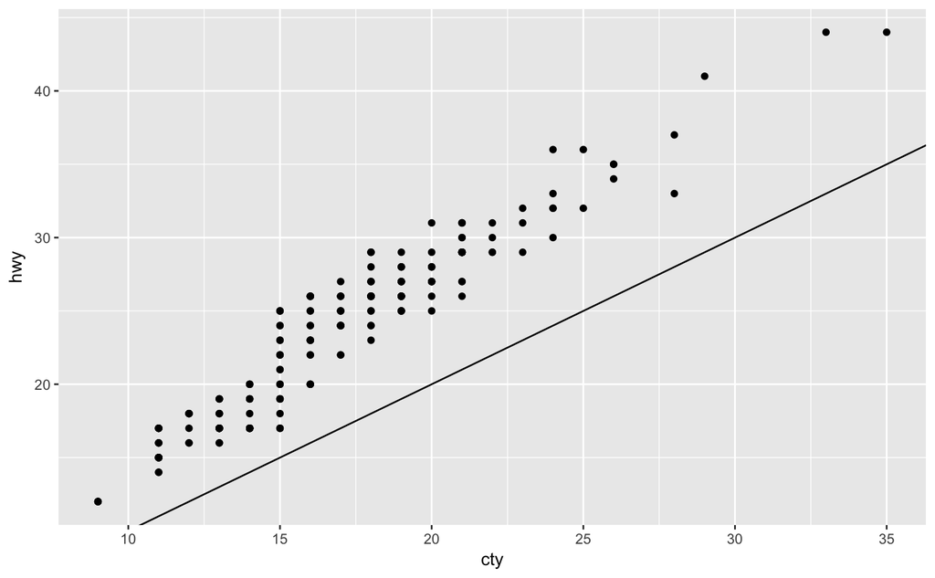

```r
# (A) Scatterplot: ------

# A minimal scatterplot + reference line:
sp1 <- ggplot(mpg) +
  geom_point(aes(x = cty, y = hwy)) +
  geom_abline()
sp1
```

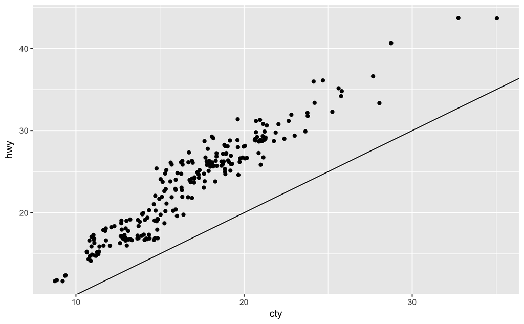

```r
# Note a potential issue: Overplotting (multiple points on the same position).


# (B) Overplotting: -----

# One way of dealing with overplotting is
# adding randomness to point positions:
sp2 <- ggplot(mpg) +
  geom_point(aes(x = cty, y = hwy), position = "jitter") +
  geom_abline()
sp2
```

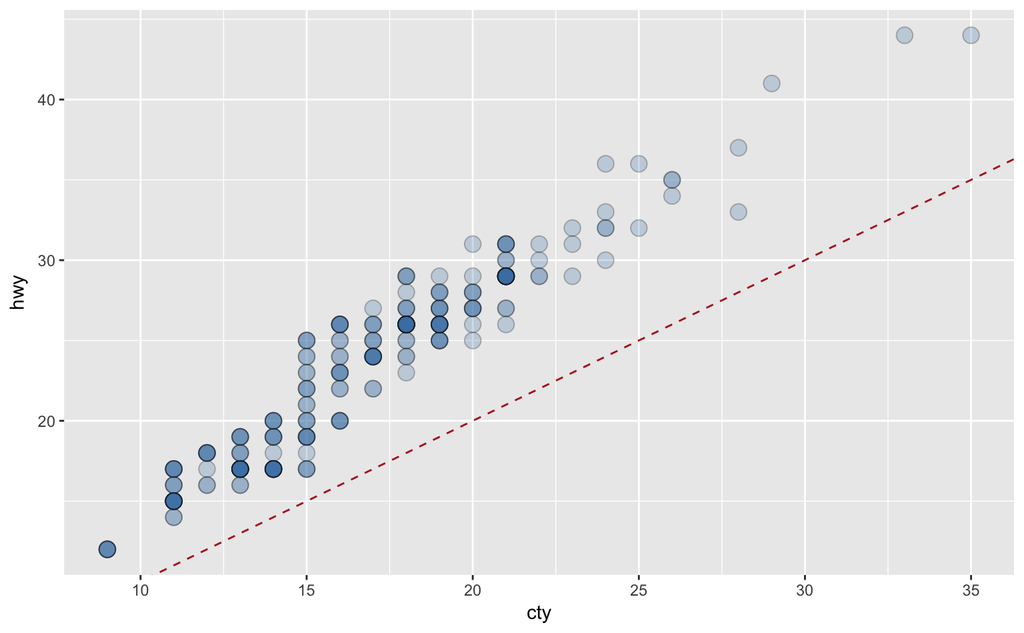

```r
# Another way of dealing with overplotting is
# using transparency (via setting alpha to < 1):
sp3 <- ggplot(mpg) +
  geom_point(aes(x = cty, y = hwy), position = "identity",
             pch = 21, fill = "steelblue", alpha = 1/4, size = 4) +
  geom_abline(linetype = 2, color = "firebrick") # +
  # geom_rug(aes(x = cty, y = hwy), position = "jitter", alpha = 1/4, size = 1)
sp3
```

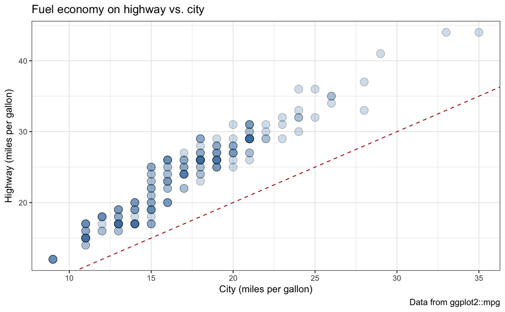

```r
# Adding labels and themes to plots:
sp4 <- sp3 +   # use the plot defined above
  labs(title = "Fuel economy on highway vs. city",
                x = "City (miles per gallon)",
                y = "Highway (miles per gallon)",
                caption = "Data from ggplot2::mpg") +
  # coord_fixed() +
  theme_bw()
sp4
```

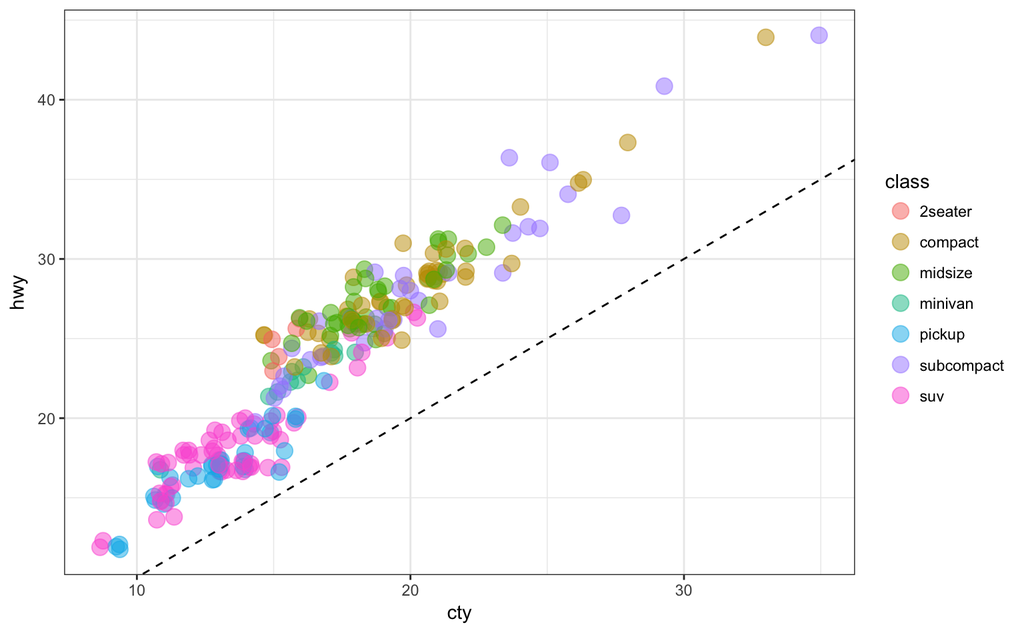

```r
# (C) Grouping (by a categorical variable): ------

# Grouping by color:
sp5 <- ggplot(mpg) +
  geom_point(aes(x = cty, y = hwy, color = class),
             position = "jitter", alpha = 1/2, size = 4) +
  geom_abline(linetype = 2) +
  theme_bw()
sp5
```

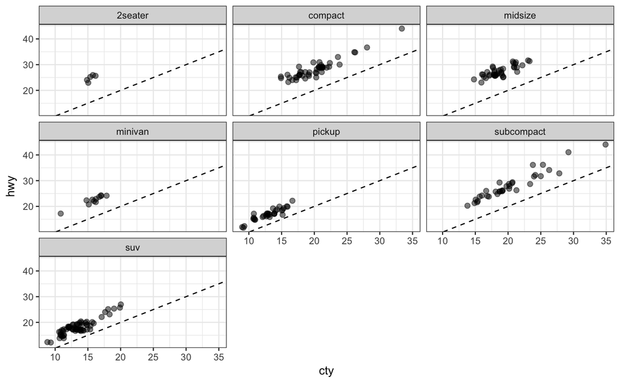

```r
# Grouping by facets:
sp6 <- ggplot(mpg) +
  geom_point(aes(x = cty, y = hwy),
             position = "jitter", alpha = 1/2, size = 2) +
  geom_abline(linetype = 2) +
  facet_wrap(~class) +
  theme_bw()
sp6
```

See https://ggplot2.tidyverse.org/reference/ for more examples.

Note some details:

- `ggplot` requires data and maps independent variables to dimensions (e.g., the x- and y-axis) and dependent variables to geometric objects (called “geoms”). It typically assumes that the to-be-plotted `<DATA>` is in a table (data frame or tibble) in long format and contains independent variables as factors.
- The arguments `data =` and `mappings =` can be omitted, but an aesthetic mapping `aes(<MAPPING>)` for at least one geom is needed.
- Different geoms can be combined, but their order matters (as later layers are printed on top of earlier ones).
- When multiple geoms use the same mappings, their common `aes(<MAPPING>)` can be moved into the initial `ggplot` call (behind `<DATA>`).
- In `ggplot`, a sequence of commands is combined by `+`, rather than `%>%`.
- The visual appearance of plots are highly customizable (e.g., by supplying aesthetic arguments, speciying labels and legends, and applying pre-defined themes to plots).

## EDA

The key to creating a good graph involves 2 steps:

1. Knowing the number and type of variables to be plotted.
2. Knowing the intended type of graph (i.e., knowing the available ones and identifying the suitable ones).

Even when 1. and 2. is given, creating good graphs with `ggplot` requires a lot of practice and many hours of trial-and-error experimentation.

### Scatterplots

Trendlines

### Other plots and packages

`ggplot2` comes with a large variety of geoms. Nevertheless, we sometimes want to show or do something that is not included in the standard package. [Chapter 7: Exploratory data analysis](http://r4ds.had.co.nz/exploratory-data-analysis.html) goes beyond standard `ggplot` geoms by touching on `geom_hex` (from the `hexbin` package) and `geom_beeswarm` and `geom_quasirandom` (from the `ggbeeswarm` package). When looking for new forms of visual expression, web sites like

- [Data Visualization Catalogue](https://datavizcatalogue.com)
- [Google charts](https://developers.google.com/chart/)
- [R-graph gallery](http://www.r-graph-gallery.com)

can inspire and provide many interesting pointers. The site

- [ggplot2-exts.org](https://www.ggplot2-exts.org/)

also provides valuable resources for `ggplot` users, as it shows packages specifically designed to work with `ggplot2`. In the following, we illustrate the package `ggalluvial` that allows showing the transitions between categorical data.

#### Example 1: Alluvial plot

```r
# Preparations:
library(tidyverse)
# install.packages("ggalluvial")
library(ggalluvial)

# Example 1 (adapted from vignette): -----

as_tibble(as.data.frame(UCBAdmissions))
```

```
#> # A tibble: 24 x 4
#>       Admit Gender   Dept  Freq
#>      <fctr> <fctr> <fctr> <dbl>
#>  1 Admitted   Male      A   512
#>  2 Rejected   Male      A   313
#>  3 Admitted Female      A    89
#>  4 Rejected Female      A    19
#>  5 Admitted   Male      B   353
#>  6 Rejected   Male      B   207
#>  7 Admitted Female      B    17
#>  8 Rejected Female      B     8
#>  9 Admitted   Male      C   120
#> 10 Rejected   Male      C   205
#> # ... with 14 more rows
```

```r
is_alluvial(as.data.frame(UCBAdmissions), logical = FALSE, silent = TRUE)
```

```
#> [1] "alluvia"
```

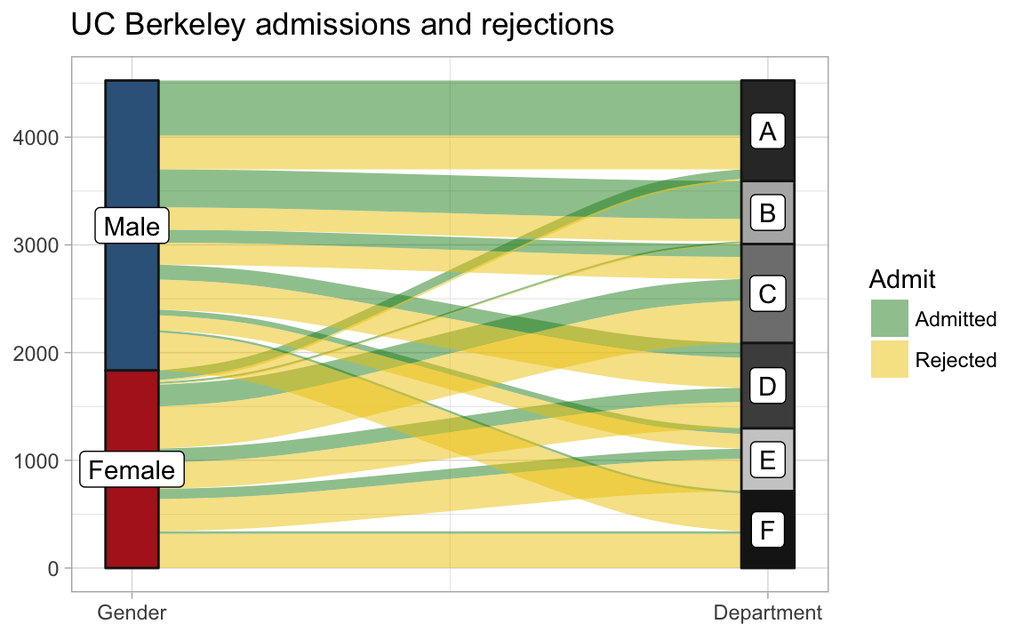

```r
ggplot(as.data.frame(UCBAdmissions),
       aes(weight = Freq, axis1 = Gender, axis2 = Dept)) +
  geom_alluvium(aes(fill = Admit), width = 1/12) +
  geom_stratum(width = 1/12,
               fill = c("firebrick", "steelblue4", "grey10", "grey80", "grey30", "grey50", "grey70", "grey20"),
               color = "grey10") +
  geom_label(stat = "stratum", label.strata = TRUE) +
  scale_x_continuous(breaks = 1:2, labels = c("Gender", "Department")) +
  # scale_fill_brewer(type = "qual", palette = "Set2") +
  scale_fill_manual(values = c("forestgreen", "gold2")) +
  ggtitle("UC Berkeley admissions and rejections") +
  theme_light()
```

An important feature of these diagrams is the meaningfulness of the vertical axis: No gaps are inserted between the strata, so the total height of the diagram reflects the cumulative weight of the observations.[^1]

#### Example 2: Parallel set diagram

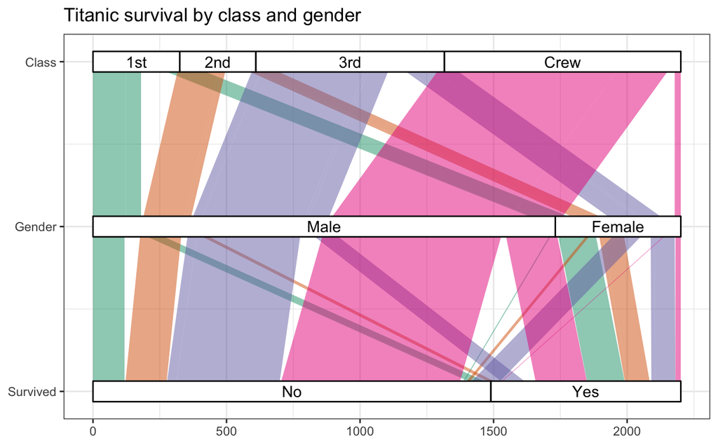

```r
# Preparations:
library(ggalluvial)

# Example 2 (adapted from vignette): -----

# as.data.frame(Titanic)

ggplot(as.data.frame(Titanic),
       aes(weight = Freq,
           axis1 = Survived, axis2 = Sex, axis3 = Class)) +
  geom_alluvium(aes(fill = Class),
                width = 0, knot.pos = 0, reverse = FALSE) +
  guides(fill = FALSE) +
  geom_stratum(width = 1/8, reverse = FALSE) +
  geom_text(stat = "stratum", label.strata = TRUE, reverse = FALSE) +
  scale_x_continuous(breaks = 1:3, labels = c("Survived", "Gender", "Class")) +
  coord_flip() +
  ggtitle("Titanic survival by class and gender") +
  scale_fill_brewer(type = "qual", palette = "Dark2") +
  theme_bw()
```

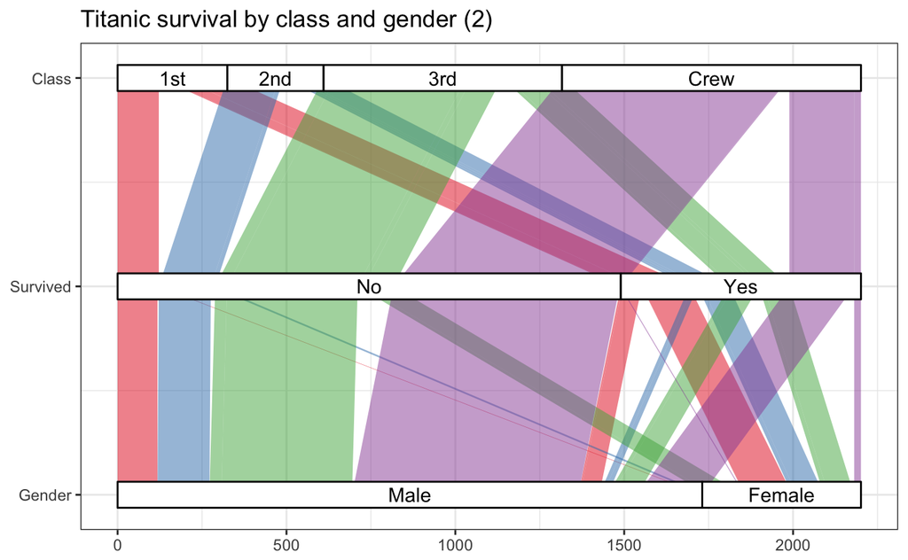

```r
# Switching order of axes (to put Survived in middle):

ggplot(as.data.frame(Titanic),
       aes(weight = Freq,
           axis1 = Sex, axis2 = Survived, axis3 = Class)) +
  geom_alluvium(aes(fill = Class),
                width = 0, knot.pos = 0, reverse = FALSE) +
  guides(fill = FALSE) +
  geom_stratum(width = 1/8, reverse = FALSE) +
  geom_text(stat = "stratum", label.strata = TRUE, reverse = FALSE) +
  scale_x_continuous(breaks = 1:3, labels = c("Gender", "Survived", "Class")) +
  coord_flip() +
  ggtitle("Titanic survival by class and gender (2)") +
  scale_fill_brewer(type = "qual", palette = "Set1") +
  theme_bw()
```

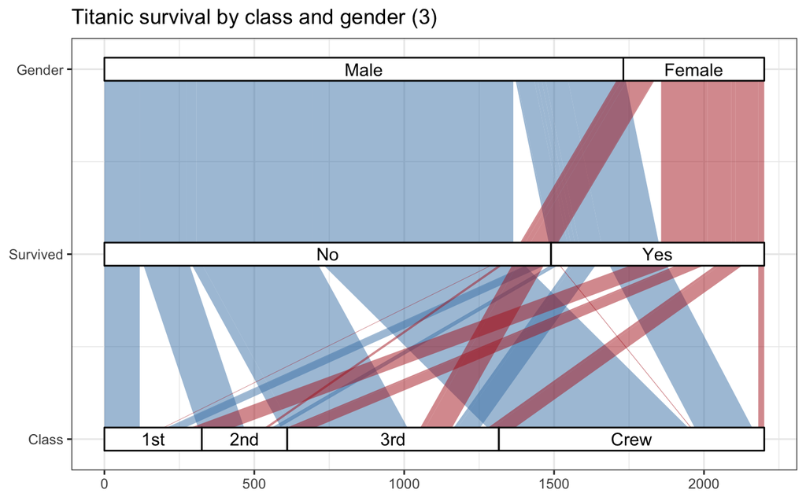

```r
# Fill by gender:

ggplot(as.data.frame(Titanic),
       aes(weight = Freq,
           axis1 = Class, axis2 = Survived, axis3 = Sex)) +
  geom_alluvium(aes(fill = Sex),
                width = 0, knot.pos = 0, reverse = FALSE) +
  guides(fill = FALSE) +
  geom_stratum(width = 1/8, reverse = FALSE) +
  geom_text(stat = "stratum", label.strata = TRUE, reverse = FALSE) +
  scale_x_continuous(breaks = 1:3, labels = c("Class", "Survived", "Gender")) +
  coord_flip() +
  ggtitle("Titanic survival by class and gender (3)") +
  # scale_fill_brewer(type = "qual", palette = "Paired") +
  scale_fill_manual(values = c("steelblue", "firebrick")) +
  theme_bw()
```

#### Example 3: Data in long format

```r
# Preparations:
library(ggalluvial)

# Example 3 (adapted from vignette): -----

?majors
data(majors)
as_tibble(majors) # illustrating lode format
```

```
#> # A tibble: 80 x 3
#>    student semester  curriculum
#>      <int>   <fctr>       <chr>
#>  1       1    CURR1    Painting
#>  2       2    CURR1    Painting
#>  3       6    CURR1    Sculpure
#>  4       8    CURR1    Painting
#>  5       9    CURR1    Sculpure
#>  6      10    CURR1    Painting
#>  7      11    CURR1 Digital Art
#>  8      12    CURR1    Sculpure
#>  9      14    CURR1     Ceramic
#> 10      15    CURR1 Photography
#> # ... with 70 more rows
```

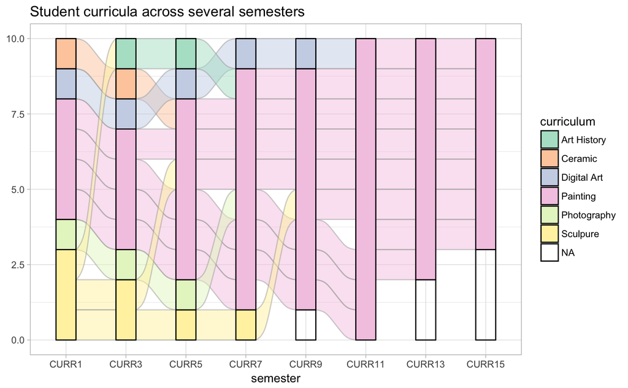

```r
majors$curriculum <- as.factor(majors$curriculum)

ggplot(majors,
       aes(x = semester, stratum = curriculum, alluvium = student,
           fill = curriculum, label = curriculum)) +
  scale_fill_brewer(type = "qual", palette = "Pastel2") +
  geom_flow(stat = "alluvium",
            lode.guidance = "rightleft",
            color = "darkgray") +
  geom_stratum() +
  theme(legend.position = "right") + # "bottom" "top"
  ggtitle("Student curricula across several semesters") +
  theme_light()
```

See the packages `circlize`, `ggforce`, and `ggparallel` for other types of transition plots.

## More on data visualization

- study `vignette("ggplot")` and the documentation for `ggplot` and various geoms (e.g., `geom_`);
- study https://ggplot2.tidyverse.org/reference/ and its examples;
- see the [cheat sheet on data visualization](https://www.rstudio.com/resources/cheatsheets/);
- read [Chapter 3: Data visualization](http://r4ds.had.co.nz/data-visualisation.html) and [Chapter 7: Exploratory data analysis (EDA)](http://r4ds.had.co.nz/exploratory-data-analysis.html) and complete their exercises.

# Conclusion

All [ds4psy](http://rpository.com/ds4psy/) essentials:

| Nr. | Topic |
| --- | --- |
| 1. | [Creating and using tibbles](http://rpository.com/ds4psy/R/_essentials/tibble.html) |
| 2. | [Data transformation](http://rpository.com/ds4psy/R/_essentials/transform.html) |
| 3. | [Visualizing data](http://rpository.com/ds4psy/R/_essentials/visualize.html) |

[Last update on 2018-06-30 09:10:12 by [hn](http://neth.de/).]

[^1]: This is different in *Sankey diagrams*, shown https://developers.google.com/chart/interactive/docs/gallery/sankey.